# Water Quality and Potability

We are collecting a dataset on water quality to train a machine learning model for binary classification: determining whether water is safe for consumption (1) or not (0). This model will help with water treatment decisions and ensure compliance with quality standards. We applied different summarization and plotting methods to help us to understand our dataset, such as scatter, histogram and bar plot. Then, we applyed preprocess in our data using data cleaning, data transformation and feature selection.

```r
#library:
#install.packages("caret")
#install.packages("glmnet")
#install.packages("Boruta")
#install.packages("mlbench")
#install.packages("randomForest")
library(outliers)
library(dplyr)
library(mlbench)
library(caret)
library(glmnet)
library(Boruta)
library(ggplot2)

getwd()
```

```
[1] "C:/Users/Aish-/OneDrive/سطح المكتب"
```

```r
#setwd("/Users/mahayie/Desktop/326p")
#getwd()


View(water_potability)

str(water_potability)
```

[output not shown]

```r
summary(water_potability)
```

[output not shown]

Checking for missing values:

```r
dim(water_potability)
```

```
[1] 3276   10
```

```r
sum(is.na(water_potability))
```

```
[1] 1434
```

Remove rows with missing values

```r
water_potability = na.omit(water_potability)
View(water_potability)
```

Description: The absence of data in certain variables or columns in a dataset is referred to as missing or null values due to various reasons. It can have a negative impact on the dataset’s efficiency and the information that can be taken from it later, so we checked to see whether our data had missing or null values and eliminated these rows to produce a more efficient dataset.

Standard deviation:

```r
sd(water_potability$Turbidity)
```

```
[1] 0.7803462
```

```r
sd(water_potability$Solids)
```

```
[1] 8642.24
```

```r
sd(water_potability$Conductivity)
```

```
[1] 80.71257
```

```r
sd(water_potability$Organic_carbon)
```

```
[1] 3.324959
```

```r
sd(water_potability$ph)
```

```
[1] 1.573337
```

Mean:

```r
mean(water_potability$Turbidity)
```

```
[1] 3.969729
```

```r
mean(water_potability$Solids)
```

```
[1] 21917.44
```

```r
mean(water_potability$Conductivity)
```

```
[1] 426.5264
```

```r
mean(water_potability$Organic_carbon)
```

```
[1] 14.35771
```

```r
mean(water_potability$ph)
```

```
[1] 7.08599
```

Median

```r
median(water_potability$Turbidity)
```

```
[1] 3.968177
```

```r
median(water_potability$Solids)
```

```
[1] 20933.51
```

```r
median(water_potability$Conductivity)
```

```
[1] 423.4559
```

```r
median(water_potability$Organic_carbon)
```

```
[1] 14.32202
```

```r
median(water_potability$ph)
```

```
[1] 7.027297
```

Variance

```r
var(water_potability$Turbidity)
```

```
[1] 0.6089401
```

```r
var(water_potability$Solids)
```

```
[1] 74688309
```

```r
var(water_potability$Conductivity)
```

```
[1] 6514.519
```

```r
var(water_potability$Organic_carbon)
```

```
[1] 11.05535
```

```r
var(water_potability$ph)
```

```
[1] 2.475388
```

Statistical Measures:

```r
summary(water_potability$Conductivity)
```

```
   Min. 1st Qu.  Median    Mean 3rd Qu.    Max.
  201.6   366.7   423.5   426.5   482.4   753.3
```

```r
summary(water_potability$Organic_carbon)
```

```
   Min. 1st Qu.  Median    Mean 3rd Qu.    Max.
   2.20   12.12   14.32   14.36   16.68   27.01
```

```r
summary(water_potability$Hardness)
```

```
   Min. 1st Qu.  Median    Mean 3rd Qu.    Max.
  73.49  176.74  197.19  195.97  216.44  317.34
```

```r
summary(water_potability$Solids)
```

```
   Min. 1st Qu.  Median    Mean 3rd Qu.    Max.
  320.9 15615.7 20933.5 21917.4 27182.6 56488.7
```

```r
summary(water_potability$Chloramines)
```

```
   Min. 1st Qu.  Median    Mean 3rd Qu.    Max.
  1.391   6.139   7.144   7.134   8.110  13.127
```

```r
summary(water_potability$Potability)
```

```
   Min. 1st Qu.  Median    Mean 3rd Qu.    Max.
 0.0000  0.0000  0.0000  0.4033  1.0000  1.0000
```

```r
summary(water_potability$Sulfate)
```

```
   Min. 1st Qu.  Median    Mean 3rd Qu.    Max.
  129.0   307.6   332.2   333.2   359.3   481.0
```

```r
summary(water_potability$Trihalomethanes)
```

```
   Min. 1st Qu.  Median    Mean 3rd Qu.    Max.
  8.577  55.953  66.542  66.401  77.292 124.000
```

```r
summary(water_potability$Turbidity)
```

```
   Min. 1st Qu.  Median    Mean 3rd Qu.    Max.
  1.450   3.443   3.968   3.970   4.514   6.495
```

```r
summary(water_potability$ph)
```

```
   Min. 1st Qu.  Median    Mean 3rd Qu.    Max.
 0.2275  6.0897  7.0273  7.0860  8.0530 14.0000
```

Descriotion: With using minimum, maximum, mean, median laws it helps to provide an overview of the data’s key characteristics

outliers before removing outlier:

```r
dim(water_potability)
```

```
[1] 2011   10
```

```r
head(water_potability)
```

|  | ph | Hardness | Solids | Chloramines | Sulfate | Conductivity | Organic_carbon | Trihalomethanes | Turbidity | Potability |
| --- | --- | --- | --- | --- | --- | --- | --- | --- | --- | --- |
| 4 | 8.316766 | 214.3734 | 22018.42 | 8.059332 | 356.8861 | 363.2665 | 18.436524 | 100.34167 | 4.628771 | 0 |
| 5 | 9.092223 | 181.1015 | 17978.99 | 6.546600 | 310.1357 | 398.4108 | 11.558279 | 31.99799 | 4.075075 | 0 |
| 6 | 5.584087 | 188.3133 | 28748.69 | 7.544869 | 326.6784 | 280.4679 | 8.399735 | 54.91786 | 2.559708 | 0 |
| 7 | 10.223862 | 248.0717 | 28749.72 | 7.513408 | 393.6634 | 283.6516 | 13.789695 | 84.60356 | 2.672989 | 0 |
| 8 | 8.635849 | 203.3615 | 13672.09 | 4.563009 | 303.3098 | 474.6076 | 12.363817 | 62.79831 | 4.401425 | 0 |
| 10 | 11.180284 | 227.2315 | 25484.51 | 9.077200 | 404.0416 | 563.8855 | 17.927806 | 71.97660 | 4.370562 | 0 |

removing outliers:

- ph

```r
summary(water_potability$ph)
```

```
   Min. 1st Qu.  Median    Mean 3rd Qu.    Max.
 0.2275  6.0897  7.0273  7.0860  8.0530 14.0000
```

```r
quartiles <- quantile(water_potability$ph, probs = c(.25, .75), na.rm = FALSE)
quartiles
```

```
     25%      75%
6.089723 8.052969
```

```r
iqr <- IQR(water_potability$ph)
iqr
```

```
[1] 1.963245
```

```r
lower <- quartiles[1] - 1.5*iqr
lower
```

```
     25%
3.144855
```

```r
upper <- quartiles[2] + 1.5*iqr
upper
```

```
     75%
10.99784
```

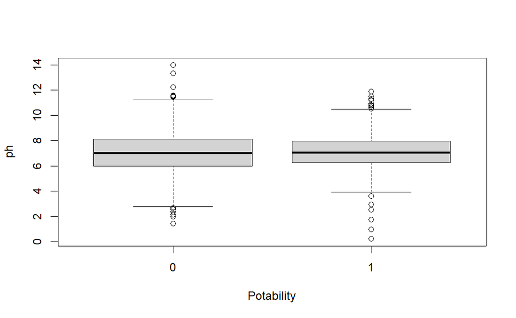

```r
boxplot(ph ~ Potability, data = water_potability)
```

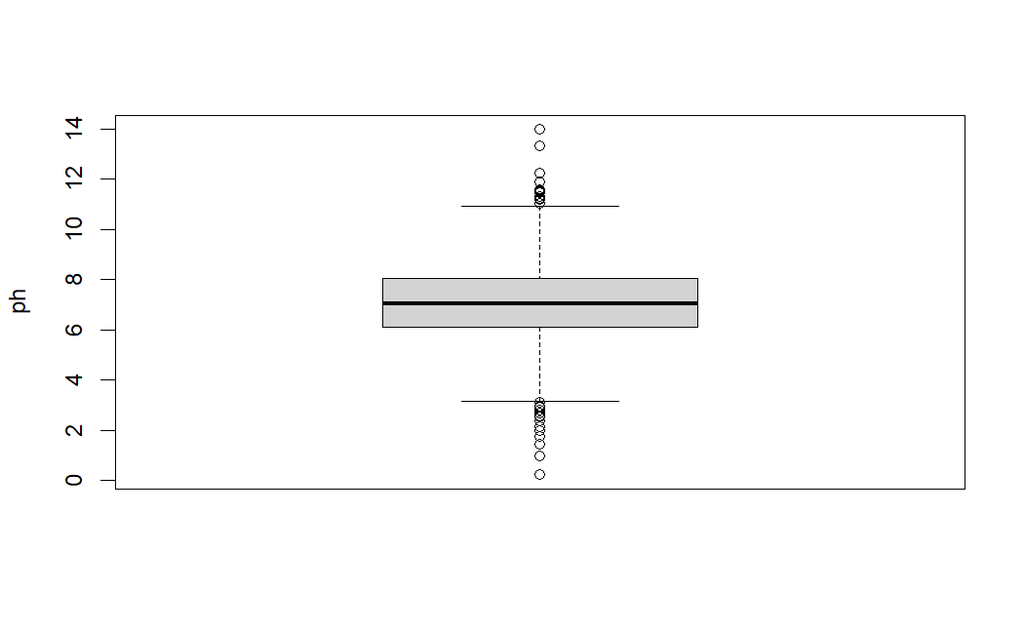

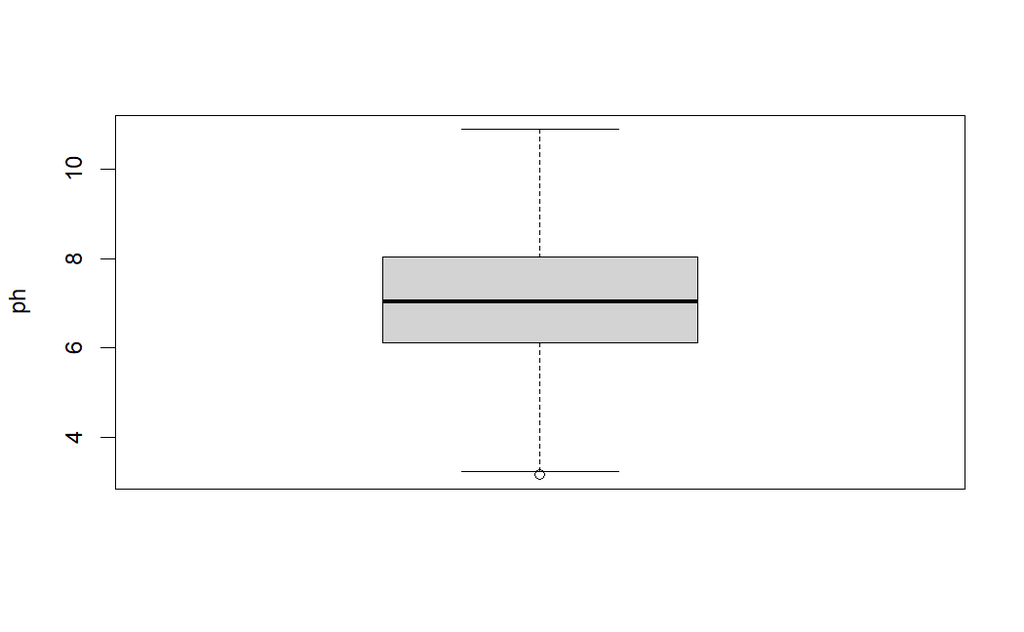

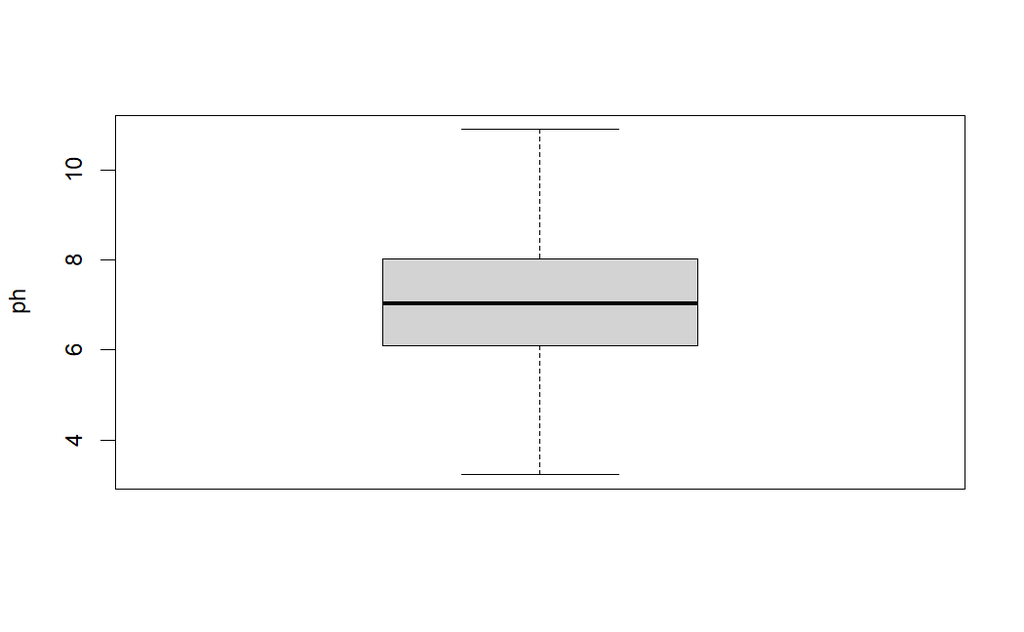

```r
repeat {
  out_val <- boxplot(water_potability$ph, ylab = 'ph')$out
  out_val
  out_rows <- which(water_potability$ph %in% c(out_val))
  out_rows

  if(sum(out_rows) > 0) water_potability <- water_potability[-out_rows,]
  else {break}
}
```

```r
summary(water_potability$ph)
```

```
   Min. 1st Qu.  Median    Mean 3rd Qu.    Max.
  3.231   6.105   7.027   7.087   8.030  10.905
```

```r
#-------------------------------------------
```

-Hardness

```r
summary(water_potability$Hardness)
```

```
   Min. 1st Qu.  Median    Mean 3rd Qu.    Max.
  73.49  176.90  197.36  196.27  216.44  317.34
```

```r
quartiles <- quantile(water_potability$Hardness, probs = c(.25, .75), na.rm = FALSE)
quartiles
```

```
     25%      75%
176.9031 216.4411
```

```r
iqr <- IQR(water_potability$Hardness)
iqr
```

```
[1] 39.53799
```

```r
lower <- quartiles[1] - 1.5*iqr
lower
```

```
     25%
117.5961
```

```r
upper <- quartiles[2] + 1.5*iqr
upper
```

```
     75%
275.7481
```

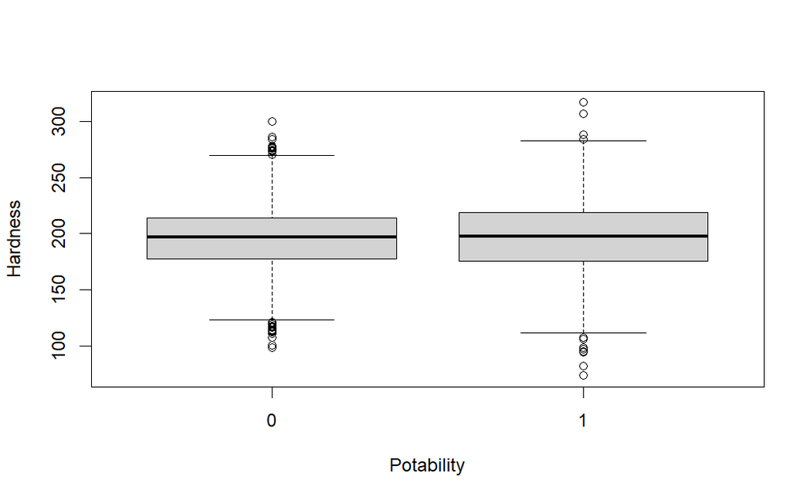

```r
boxplot(Hardness ~ Potability, data = water_potability)
```

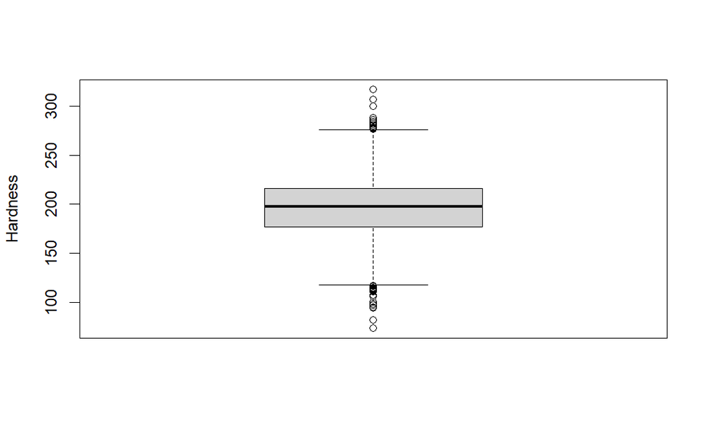

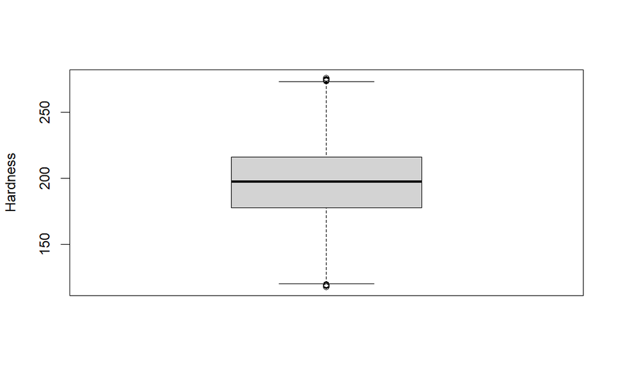

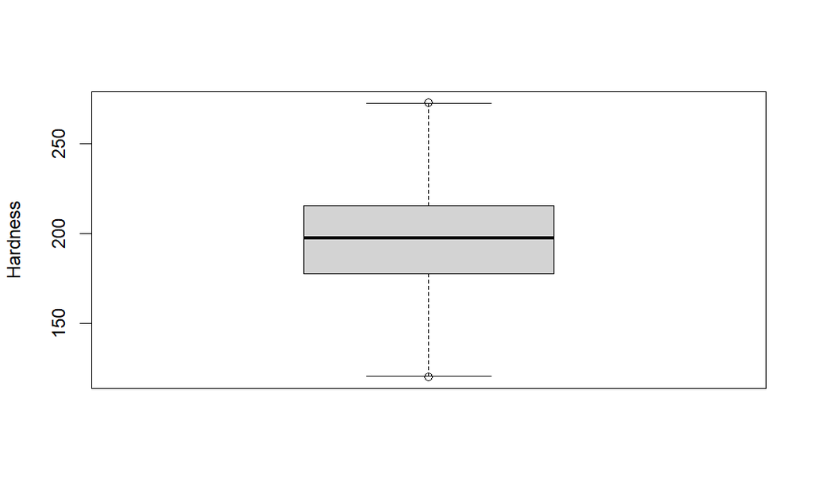

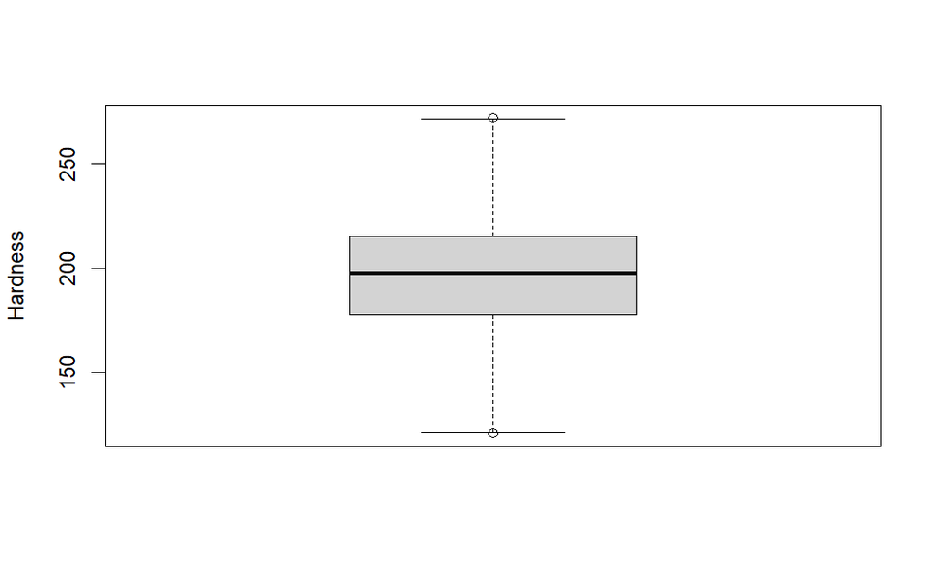

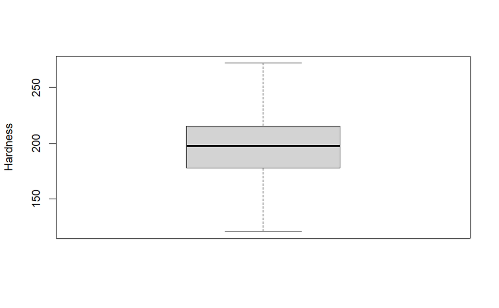

```r
repeat {
  out_val <- boxplot(water_potability$Hardness, ylab = 'Hardness')$out
  out_val
  out_rows <- which(water_potability$Hardness %in% c(out_val))
  out_rows

  if(sum(out_rows) > 0) water_potability <- water_potability[-out_rows,]
  else {break}
}
```

```r
summary(water_potability$Hardness)
```

```
   Min. 1st Qu.  Median    Mean 3rd Qu.    Max.
  121.0   177.7   197.3   196.2   215.5   272.1
```

```r
#-------------------------------------------
```

-Solids

```r
summary(water_potability$Solids)
```

```
   Min. 1st Qu.  Median    Mean 3rd Qu.    Max.
  320.9 15704.5 20855.3 21840.2 27045.9 56488.7
```

```r
quartiles <- quantile(water_potability$Solids, probs = c(.25, .75), na.rm = FALSE)
quartiles
```

```
     25%      75%
15704.48 27045.93
```

```r
iqr <- IQR(water_potability$Solids)
iqr
```

```
[1] 11341.45
```

```r
lower <- quartiles[1] - 1.5*iqr
lower
```

```
     25%
-1307.69
```

```r
upper <- quartiles[2] + 1.5*iqr
upper
```

```
    75%
44058.1
```

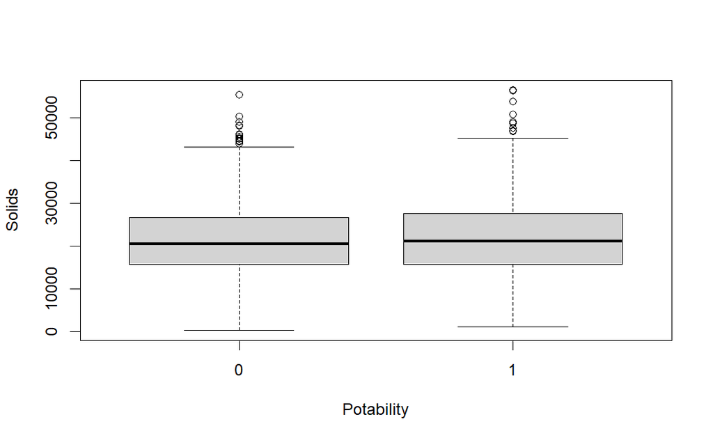

```r
boxplot(Solids ~ Potability, data = water_potability)
```

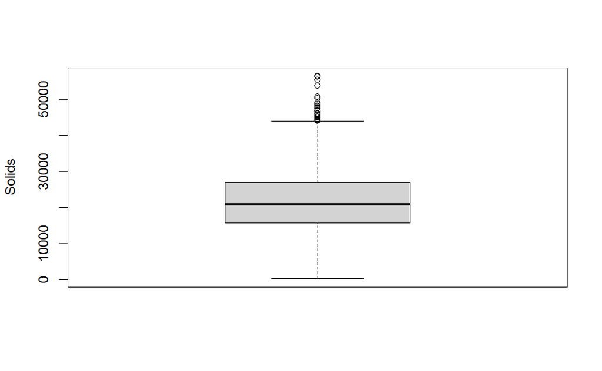

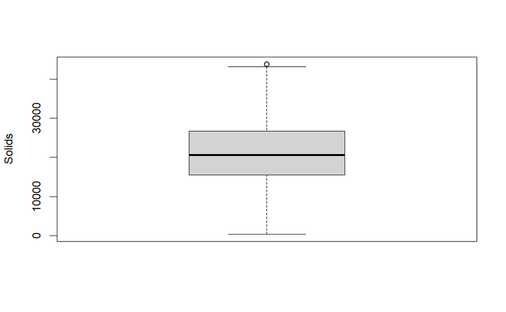

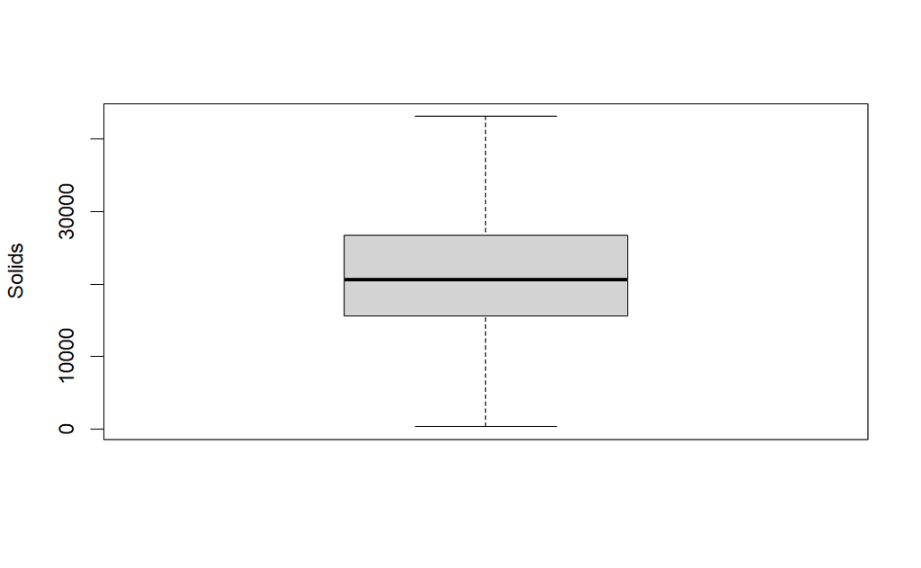

```r
repeat {
  out_val <- boxplot(water_potability$Solids, ylab = 'Solids')$out
  out_val
  out_rows <- which(water_potability$Solids %in% c(out_val))
  out_rows

  if(sum(out_rows) > 0) water_potability <- water_potability[-out_rows,]
  else {break}
}
```

```r
summary(water_potability$Solids)
```

```
   Min. 1st Qu.  Median    Mean 3rd Qu.    Max.
  320.9 15547.5 20518.7 21419.6 26734.7 43195.5
```

```r
#-------------------------------------------
```

-Chloramines

```r
summary(water_potability$Chloramines)
```

```
   Min. 1st Qu.  Median    Mean 3rd Qu.    Max.
  1.391   6.141   7.135   7.135   8.094  13.127
```

```r
quartiles <- quantile(water_potability$Chloramines, probs = c(.25, .75), na.rm = FALSE)
quartiles
```

```
     25%      75%
6.141236 8.094323
```

```r
iqr <- IQR(water_potability$Chloramines)
iqr
```

```
[1] 1.953087
```

```r
lower <- quartiles[1] - 1.5*iqr
lower
```

```
     25%
3.211605
```

```r
upper <- quartiles[2] + 1.5*iqr
upper
```

```
     75%
11.02395
```

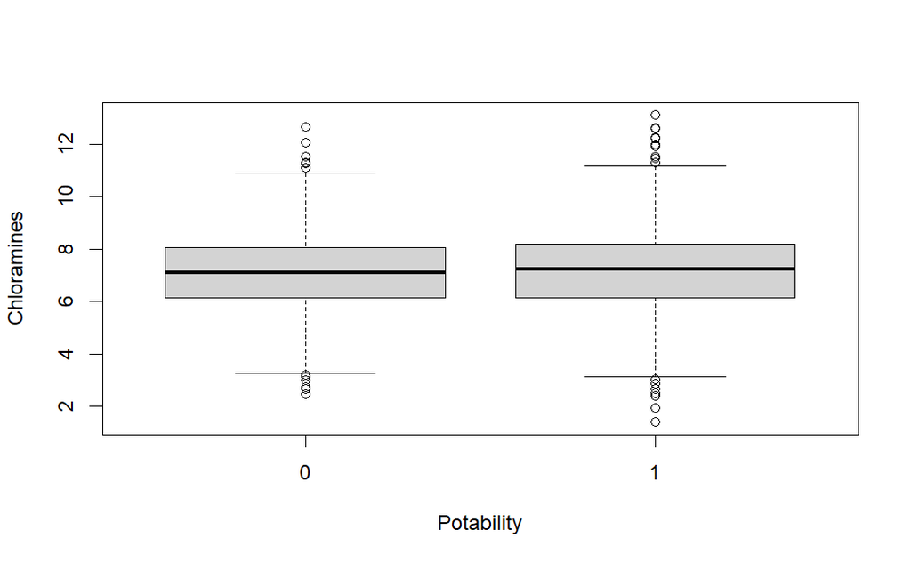

```r
boxplot(Chloramines ~ Potability, data = water_potability)
```

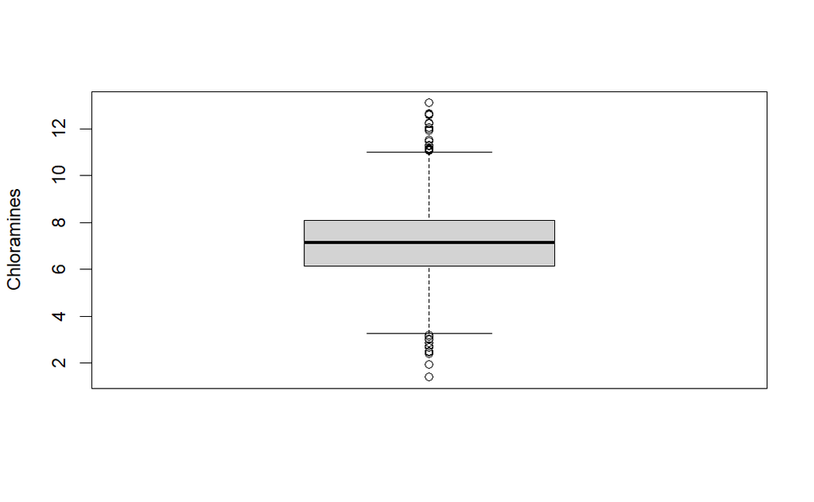

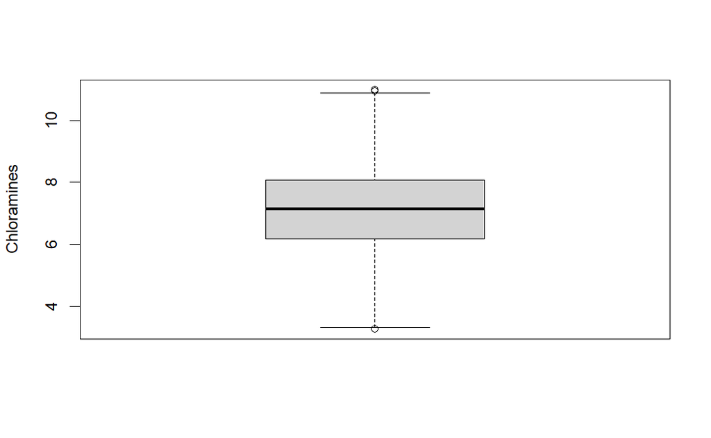

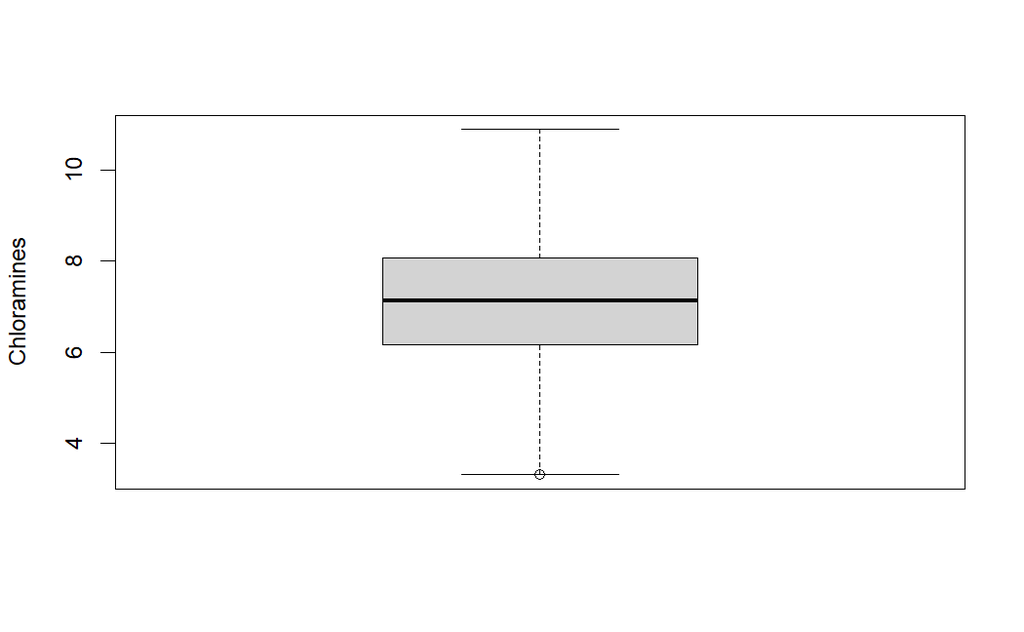

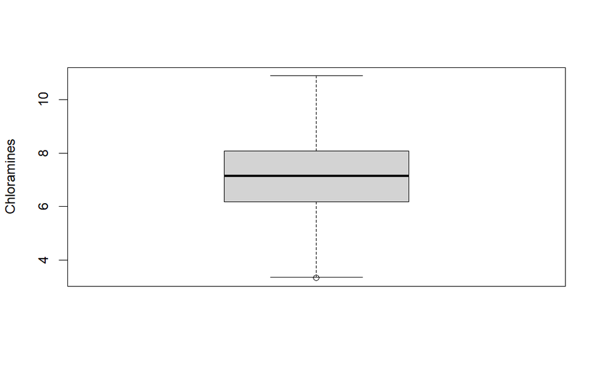

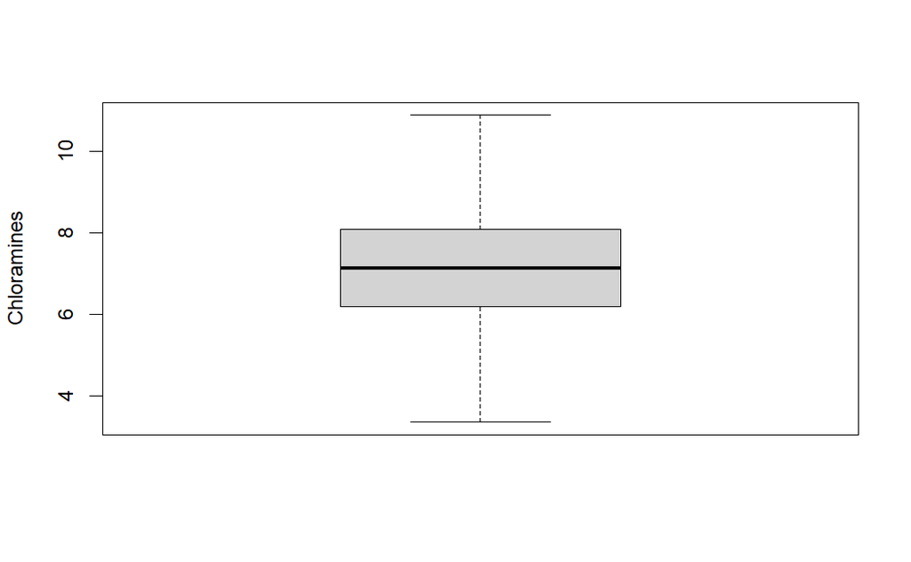

```r
repeat {
  out_val <- boxplot(water_potability$Chloramines, ylab = 'Chloramines')$out
  out_val
  out_rows <- which(water_potability$Chloramines %in% c(out_val))
  out_rows

  if(sum(out_rows) > 0) water_potability <- water_potability[-out_rows,]
  else {break}
}
```

```r
summary(water_potability$Chloramines)
```

```
   Min. 1st Qu.  Median    Mean 3rd Qu.    Max.
  3.352   6.181   7.137   7.136   8.076  10.897
```

```r
#-------------------------------------------
```

-Sulfate

```r
summary(water_potability$Sulfate)
```

```
   Min. 1st Qu.  Median    Mean 3rd Qu.    Max.
  187.2   308.2   332.6   333.4   358.3   481.0
```

```r
quartiles <- quantile(water_potability$Sulfate, probs = c(.25, .75), na.rm = FALSE)
quartiles
```

```
     25%      75%
308.1884 358.3020
```

```r
iqr <- IQR(water_potability$Sulfate)
iqr
```

```
[1] 50.11358
```

```r
lower <- quartiles[1] - 1.5*iqr
lower
```

```
     25%
233.0181
```

```r
upper <- quartiles[2] + 1.5*iqr
upper
```

```
     75%
433.4724
```

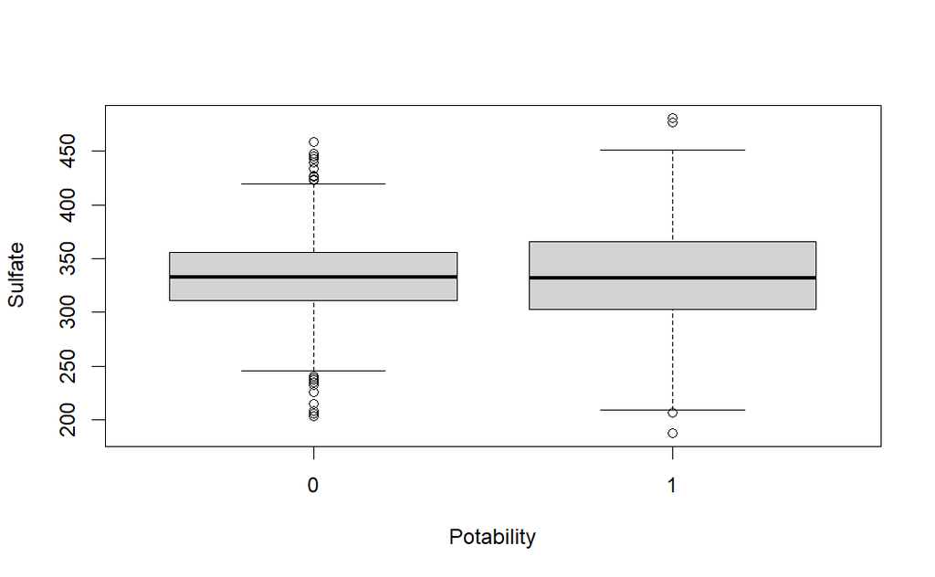

```r
boxplot(Sulfate ~ Potability, data = water_potability)
```

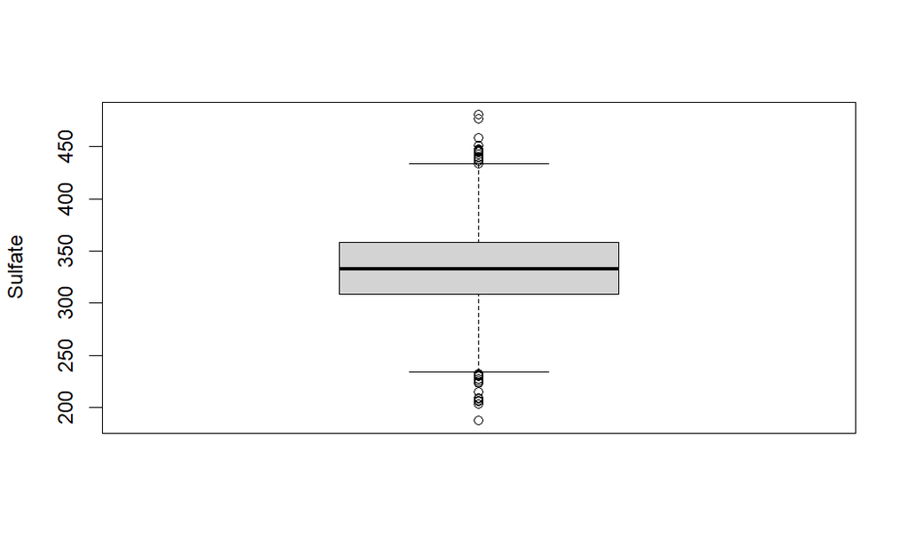

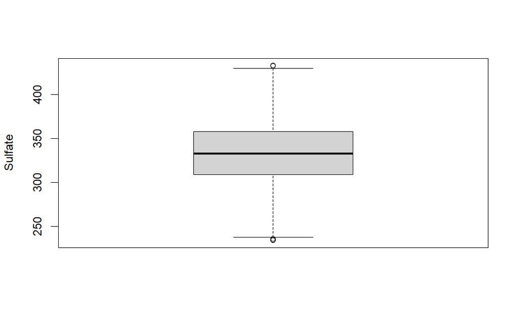

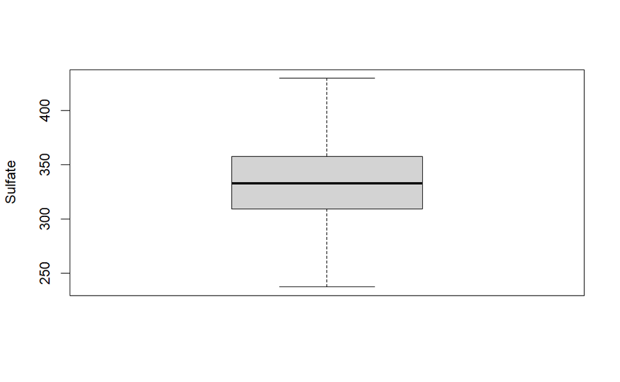

```r
repeat {
  out_val <- boxplot(water_potability$Sulfate, ylab = 'Sulfate')$out
  out_val
  out_rows <- which(water_potability$Sulfate %in% c(out_val))
  out_rows

  if(sum(out_rows) > 0) water_potability <- water_potability[-out_rows,]
  else {break}
}
```

```r
summary(water_potability$Sulfate)
```

```
   Min. 1st Qu.  Median    Mean 3rd Qu.    Max.
  237.5   309.2   332.8   333.6   357.7   429.8
```

```r
#-------------------------------------------
```

-Conductivity

```r
summary(water_potability$Conductivity)
```

```
   Min. 1st Qu.  Median    Mean 3rd Qu.    Max.
  201.6   366.6   423.6   426.8   482.6   753.3
```

```r
quartiles <- quantile(water_potability$Conductivity, probs = c(.25, .75), na.rm = FALSE)
quartiles
```

```
     25%      75%
366.5581 482.5983
```

```r
iqr <- IQR(water_potability$Conductivity)
iqr
```

```
[1] 116.0401
```

```r
lower <- quartiles[1] - 1.5*iqr
lower
```

```
     25%
192.4979
```

```r
upper <- quartiles[2] + 1.5*iqr
upper
```

```
     75%
656.6585
```

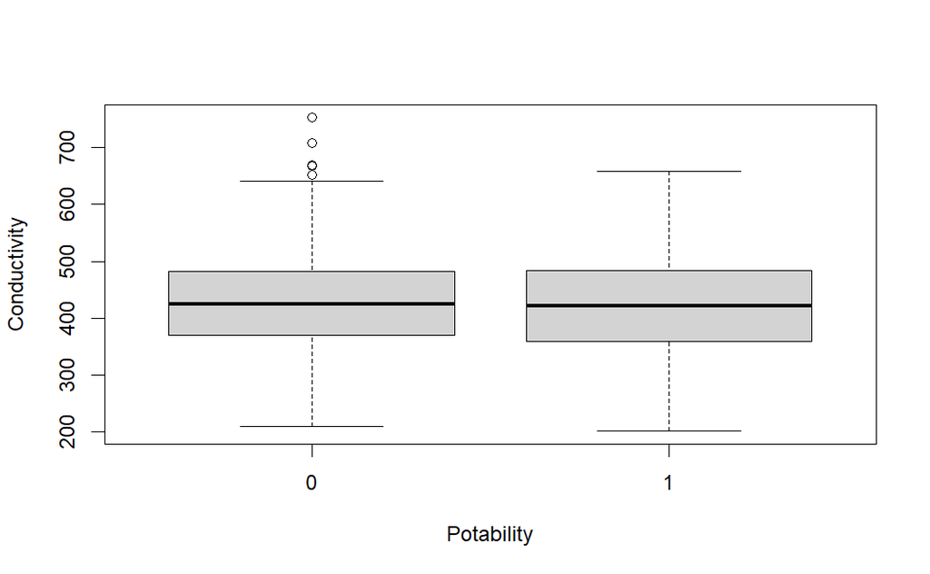

```r
boxplot(Conductivity ~ Potability, data = water_potability)
```

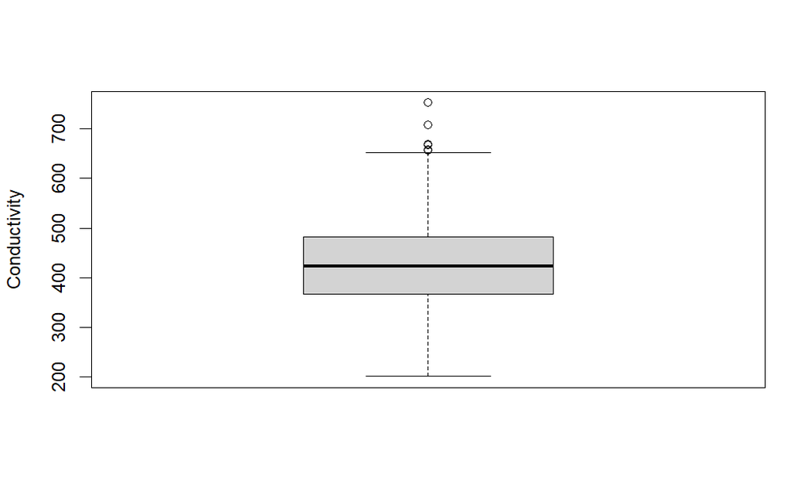

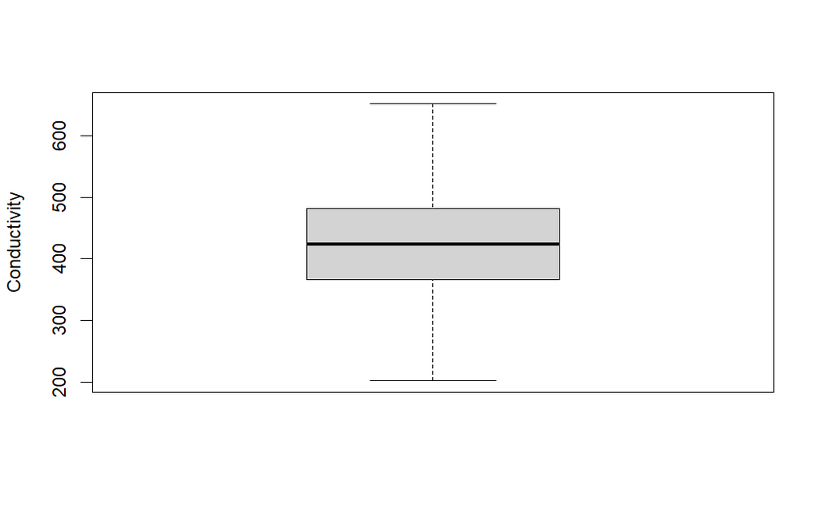

```r
repeat {
  out_val <- boxplot(water_potability$Conductivity, ylab = 'Conductivity')$out
  out_val
  out_rows <- which(water_potability$Conductivity %in% c(out_val))
  out_rows

  if(sum(out_rows) > 0) water_potability <- water_potability[-out_rows,]
  else {break}
}
```

```r
summary(water_potability$Conductivity)
```

```
   Min. 1st Qu.  Median    Mean 3rd Qu.    Max.
  201.6   366.4   423.1   426.0   481.9   652.5
```

```r
#-------------------------------------------
```

-Organic_carbon

```r
summary(water_potability$Organic_carbon)
```

```
   Min. 1st Qu.  Median    Mean 3rd Qu.    Max.
  4.372  12.184  14.351  14.417  16.788  27.007
```

```r
quartiles <- quantile(water_potability$Organic_carbon, probs = c(.25, .75), na.rm = FALSE)
quartiles
```

```
     25%      75%
12.18447 16.78779
```

```r
iqr <- IQR(water_potability$Organic_carbon)
iqr
```

```
[1] 4.603315
```

```r
lower <- quartiles[1] - 1.5*iqr
lower
```

```
     25%
5.279502
```

```r
upper <- quartiles[2] + 1.5*iqr
upper
```

```
     75%
23.69276
```

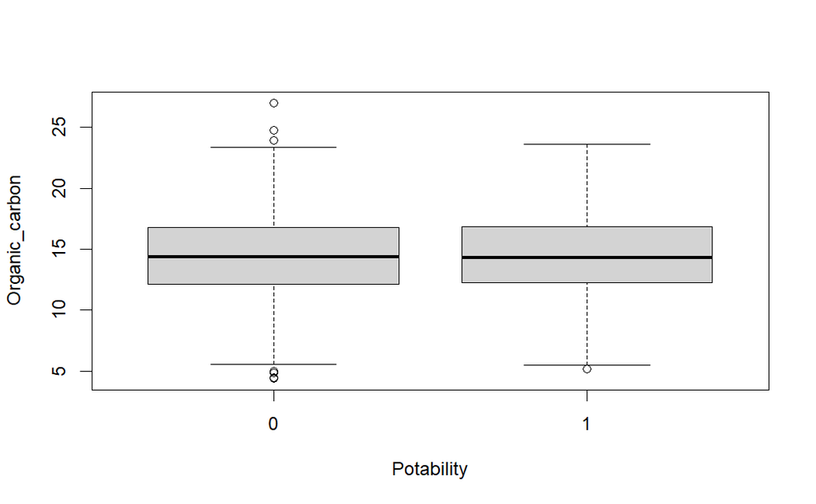

```r
boxplot(Organic_carbon ~ Potability, data = water_potability)
```

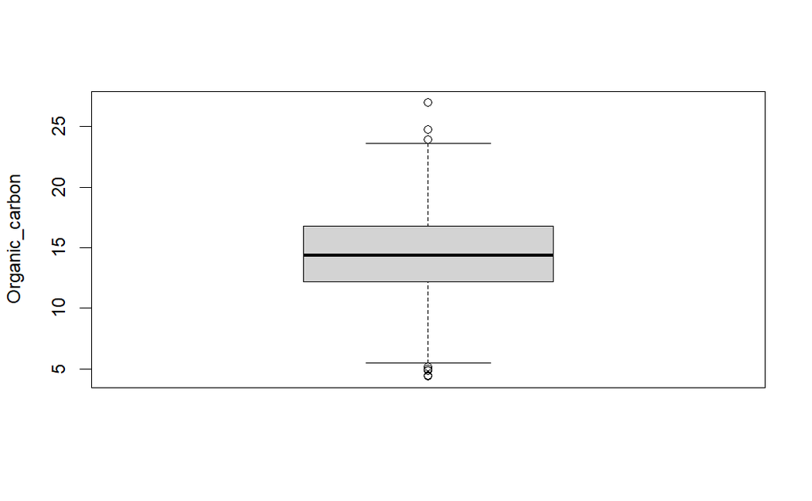

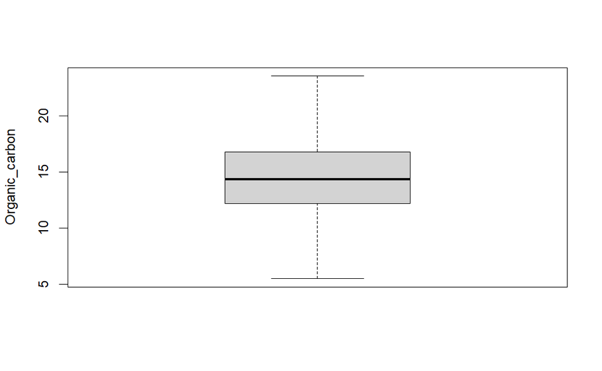

```r
repeat {
  out_val <- boxplot(water_potability$Organic_carbon, ylab = 'Organic_carbon')$out
  out_val
  out_rows <- which(water_potability$Organic_carbon %in% c(out_val))
  out_rows

  if(sum(out_rows) > 0) water_potability <- water_potability[-out_rows,]
  else {break}
}
```

```r
summary(water_potability$Organic_carbon)
```

```
   Min. 1st Qu.  Median    Mean 3rd Qu.    Max.
  5.512  12.222  14.352  14.426  16.786  23.604
```

```r
#-------------------------------------------
```

-Trihalomethanes

```r
summary(water_potability$Trihalomethanes)
```

```
   Min. 1st Qu.  Median    Mean 3rd Qu.    Max.
  8.577  55.865  66.231  66.364  77.418 124.000
```

```r
quartiles <- quantile(water_potability$Trihalomethanes, probs = c(.25, .75), na.rm = FALSE)
quartiles
```

```
     25%      75%
55.86494 77.41789
```

```r
iqr <- IQR(water_potability$Trihalomethanes)
iqr
```

```
[1] 21.55295
```

```r
lower <- quartiles[1] - 1.5*iqr
lower
```

```
     25%
23.53552
```

```r
upper <- quartiles[2] + 1.5*iqr
upper
```

```
     75%
109.7473
```

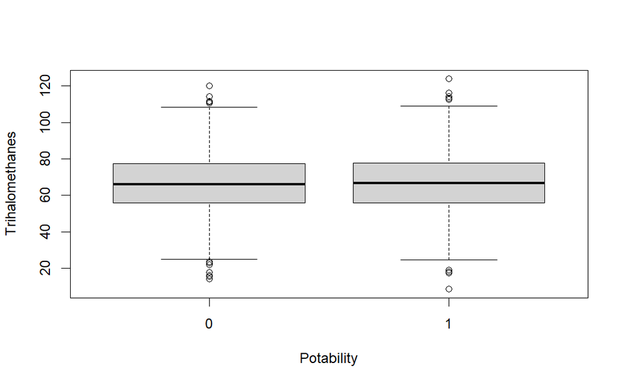

```r
boxplot(Trihalomethanes ~ Potability, data = water_potability)
```

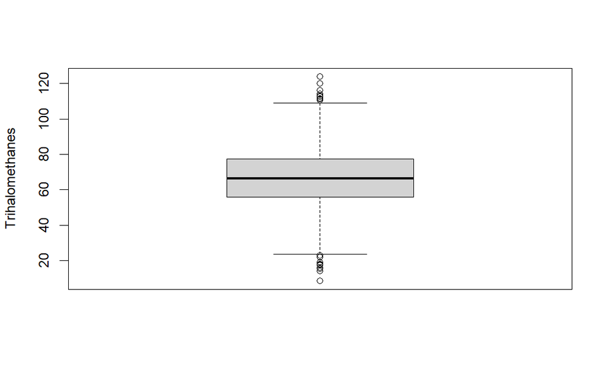

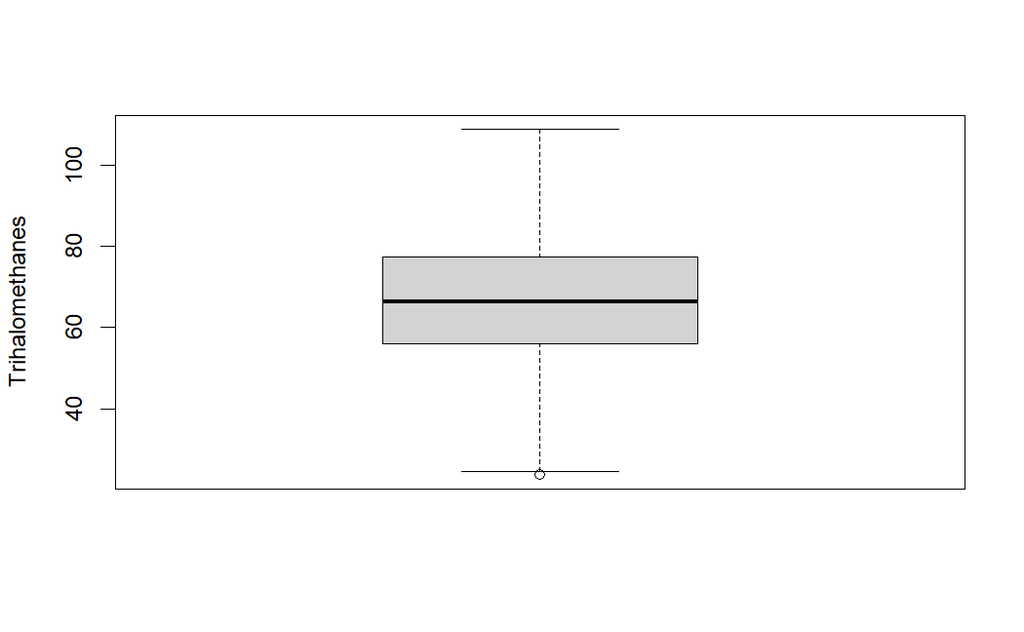

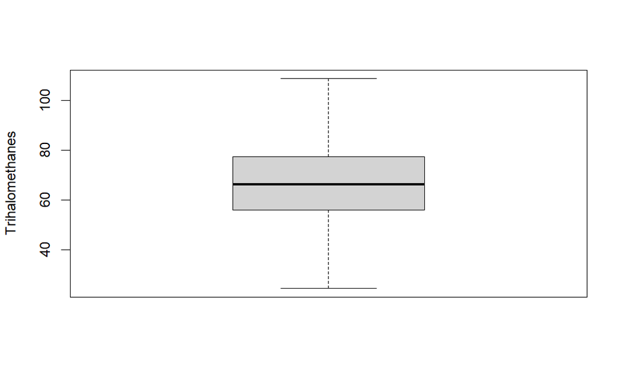

```r
repeat {
  out_val <- boxplot(water_potability$Trihalomethanes, ylab = 'Trihalomethanes')$out
  out_val
  out_rows <- which(water_potability$Trihalomethanes %in% c(out_val))
  out_rows

  if(sum(out_rows) > 0) water_potability <- water_potability[-out_rows,]
  else {break}
}
```

```r
summary(water_potability$Trihalomethanes)
```

```
   Min. 1st Qu.  Median    Mean 3rd Qu.    Max.
  24.53   55.96   66.29   66.42   77.34  108.85
```

```r
#-------------------------------------------
```

-Turbidity

```r
summary(water_potability$Turbidity)
```

```
   Min. 1st Qu.  Median    Mean 3rd Qu.    Max.
  1.450   3.441   3.975   3.973   4.519   6.495
```